# raport SAD projekt

Karol Mućk 394362

4 05 2020

```r
#Wczytanie danych
url <- "https://www.mimuw.edu.pl/~szczurek/SAD1/ZadanieZaliczeniowe/people.tab"

df <- read.table(url, sep = '\t',header = TRUE)
```

```r
head(df)
```

```
##   age weight height gender married number_of_kids      pet   expenses
## 1  25   61.7 121.12  other   FALSE              2   ferret   23.44299
## 2  37   63.9 145.00    man    TRUE              6      dog   96.83683
## 3  41   50.2 145.03  woman    TRUE              2 hedgehog  312.67693
## 4  43   72.4 179.90    man   FALSE              1      dog  447.42838
## 5  26   78.4 163.91    man   FALSE              1 hedgehog  -78.22799
## 6  49   59.4 151.86  woman    TRUE              2   ferret 1241.98263
```

W projekcie mamy do dyspozycji dane opisujące 8 różnych zmiennych. Pięć z nich jest zmiennymi ilościowymi: wiek, wzrost, waga, liczba dzieci oraz wydatki, natomiast trzy z nich są zmiennymi jakoświowymi: płeć, stan cywilny, posiadane zwierzę domowe. Łącznie mamy 500 obserwacji. Aby przyjrzeć się bliżej danym użyjemy funkcji summary.

```r
summary(df)
```

```
##       age            weight           height        gender     married
##  Min.   :17.00   Min.   : 19.40   Min.   :113.6   man  :223   Mode :logical
##  1st Qu.:33.00   1st Qu.: 57.60   1st Qu.:155.6   other: 38   FALSE:327
##  Median :39.00   Median : 66.60   Median :169.0   woman:239   TRUE :173
##  Mean   :39.48   Mean   : 66.39   Mean   :168.2
##  3rd Qu.:45.00   3rd Qu.: 75.30   3rd Qu.:180.1
##  Max.   :72.00   Max.   :107.20   Max.   :235.2
##  number_of_kids        pet         expenses
##  Min.   :0.000   cat     :105   Min.   :-685.68
##  1st Qu.:0.750   dog     :100   1st Qu.:  74.51
##  Median :1.000   ferret  : 54   Median : 402.22
##  Mean   :1.558   hedgehog: 54   Mean   : 478.60
##  3rd Qu.:2.000   none    :187   3rd Qu.: 802.72
##  Max.   :6.000                  Max.   :3503.90
```

Widzimy, że dane kompletne. Infomracje dotyczące m. in. mediany wykorzystamy później.

Możemy policzyć VIF, aby zobaczyć korelację pomiedzy danymi.

```r
buff <- lm(expenses~. ,data=df)
VIF(buff)
```

```
##                    GVIF Df GVIF^(1/(2*Df))
## age            1.008430  1        1.004206
## weight         1.822536  1        1.350013
## height         1.824757  1        1.350836
## gender         1.029538  2        1.007304
## married        1.664691  1        1.290229
## number_of_kids 1.649830  1        1.284457
## pet            1.045822  4        1.005616
```

**2)Wizualizacja danych**

Do lepszego zrozumienia danych warto je zwizualizować kilkoma wykresami.

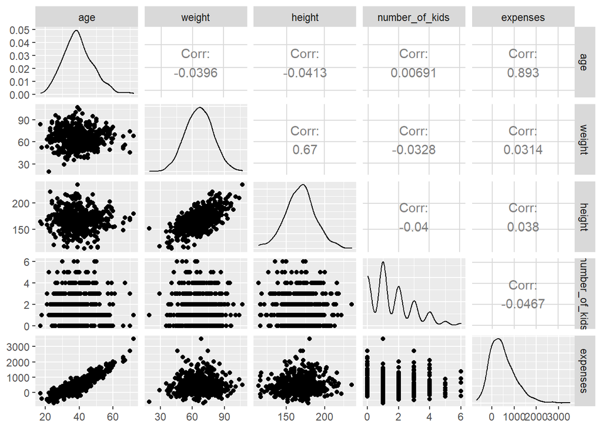

Wykres przedstawia wykresy wszystkich kombinacji zmiennych ilościowych. Widizmy, że w zmiennych waga i wzrost wystepuje liniowa korelacja, tak samo jak dla zmiennych wiek i wydadki.

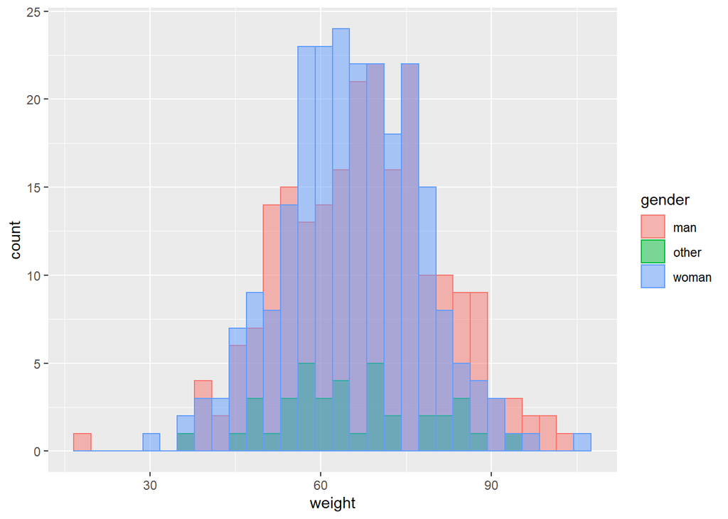

Wykres słupkowy przedstawia rozkład zmiennej waga, kolorem oznaczona jest płeć.

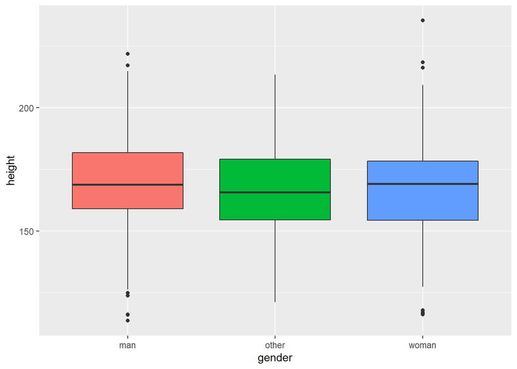

Do wizulaizacji zmiennej wzrost zastosujemy wykres pudełkowy, ponowinie kolorem zostaje oznaczona płeć.

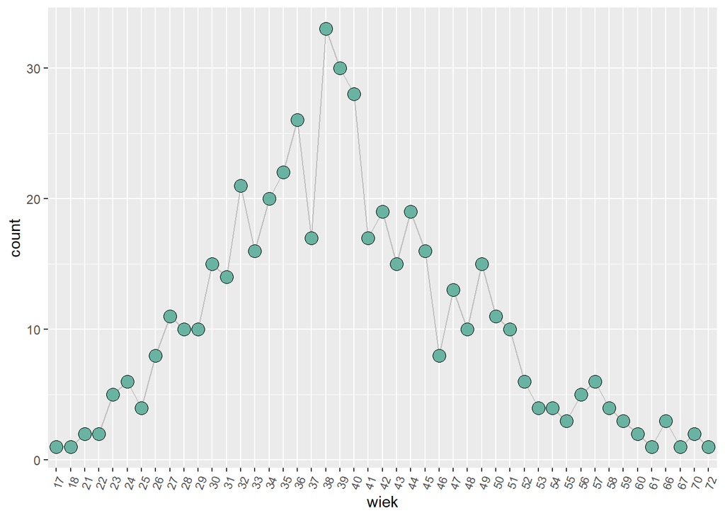

Wykres przedstawia rozkład zmiennej wiek. Widzimy, że dane zawierają głównie ludzi w średnim wieku co się zgadza z medianą która wynosi 39.

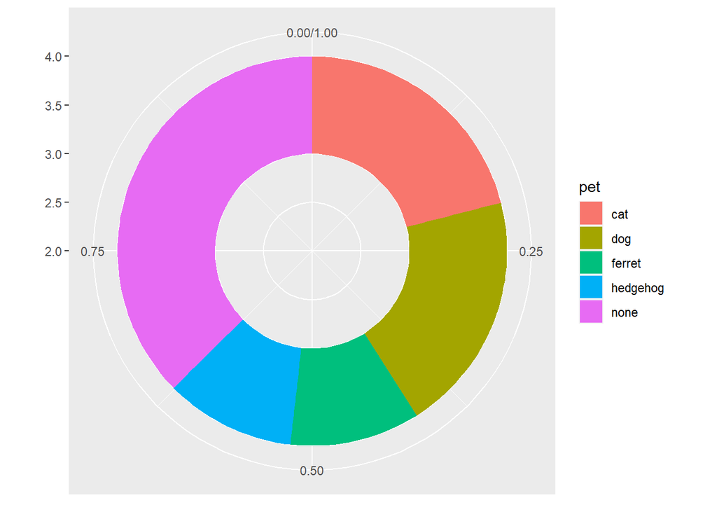

Na wykresie kołowym widać które zwierzę jest najpopularniejsze wśród naszych obserwacji. Najwięcej osób nie posiada zwierzęcia, jest to dokładnie 187 osoby.

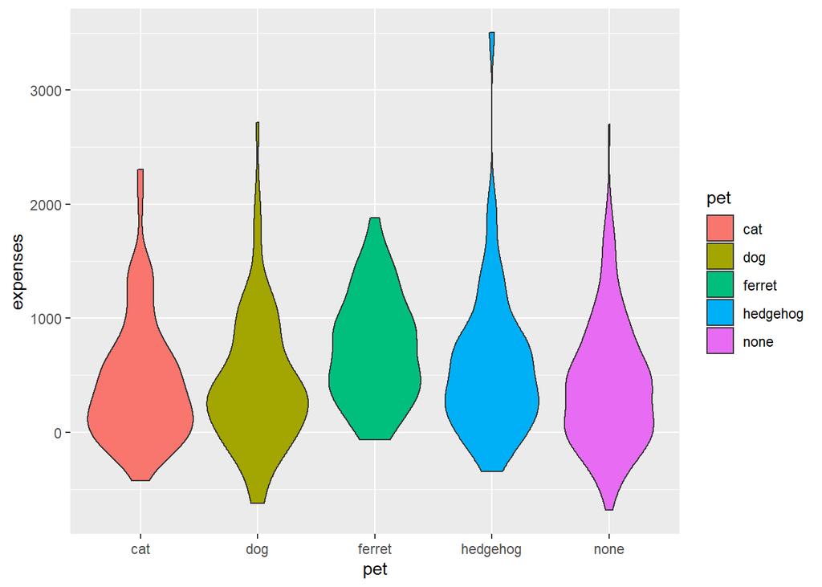

Wykres przedstawia rozkład wydadków (expenss) właścicieli róznych zierząt.

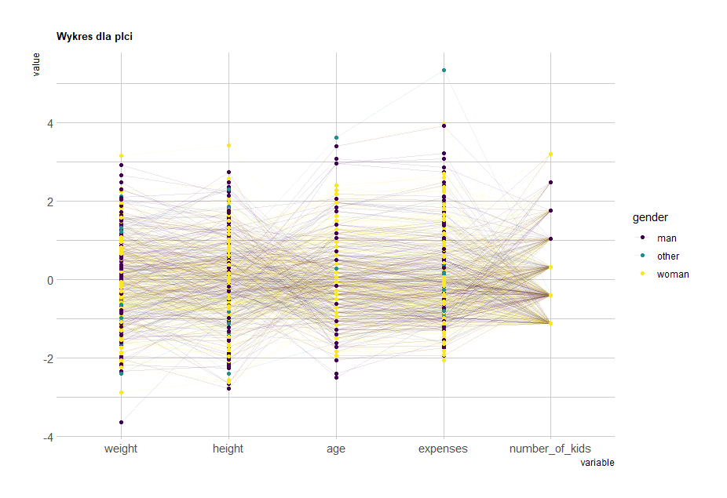

Wykres typu parallel przedstawia wszystkie zmienne na jednym wykresie, kolorem oznaczona jest płeć. Z uwagii na ilość obserwacji wykres nie jest bardzo czytelny, ale możemy z niego wyczytać, że wszystkie zmienne ilościowe nie mają korelacji z płcią. Ponownie widzimy też zależność pomiędzy wiekiem a wydatkami.

**3)przedziały ufności dla wartości średniej i wariancji dla zmiennych wiek i wzrost**

Policzymy przedział ufności zakładając, że zmienna wiek i wzrost są zmiennymi o rozkładzie normalnym, aby to sprawdzić narysujemy wykres kwantylowy dla zmiennej wiek oraz wzrost.

Zmienna wiek:

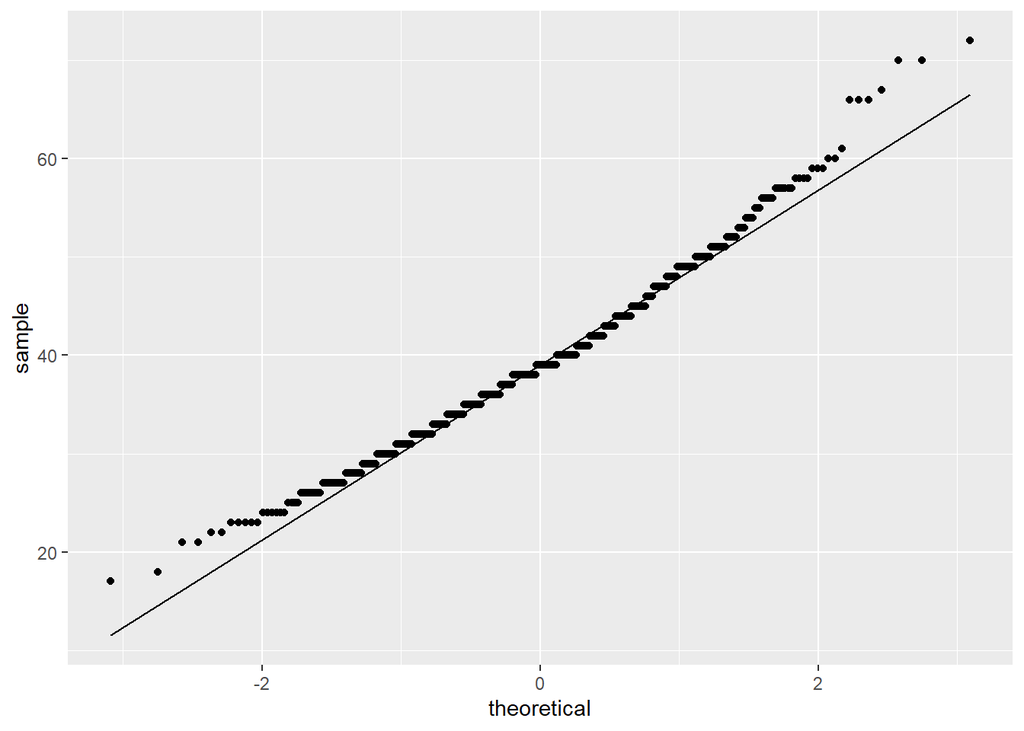

```r
ggplot(df, aes(sample = age), sub="wiek") + stat_qq()+ stat_qq_line()
```

Zmienna wzrost:

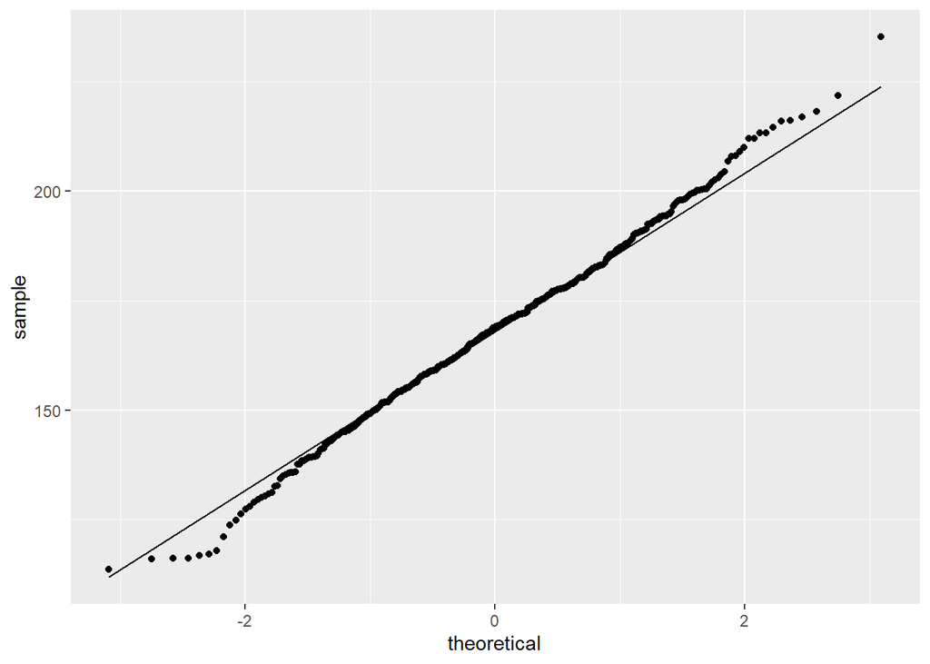

```r
ggplot(df, aes(sample = height)) + stat_qq()+ stat_qq_line()
```

```r
wiek = df[[1]]
wzrost = df[[3]]

n = length(wiek) #wiek wzorst mają tyle samo prób

#średnia z próby
mu<-mean(wiek)
mu2<-mean(wzrost)

#odchylenie standardowe
sigma<-sd(wiek)
sigma2<-sd(wzrost)
```

Ostatecznie dostajemy przedział ufności dla zmiennej wiek.

```r
round(mu+c(-1,1)*sigma/sqrt(n)*qnorm(.975),2)
```

```
## [1] 38.70 40.27
```

Oraz dla zmiennej wzrost.

```r
round(mu2+c(-1,1)*sigma2/sqrt(n)*qnorm(.975),2)
```

```
## [1] 166.46 169.90
```

Teraz policzymy przedział ufności dla wariancji o wspólczyniku ufności 0.95 dla zmiennej wiek.

```r
conf_level = 0.95

x = qchisq((1 - conf_level)/2, n-1, lower.tail = FALSE)
y = qchisq((1 - conf_level)/2, n-1)

v = var(wiek)
wiek_var = c((n-1)*v/x,(n-1)*v/y)
wiek_var
```

```
## [1] 71.44212 91.58782
```

Oraz dla zmiennej wzrost.

```r
v = var(wzrost)
wzrost_var = c((n-1)*v/x,(n-1)*v/y)
wzrost_var
```

```
## [1] 342.6017 439.2107
```

Warto tutaj zobaczyć jak wyglądają przedziały ufności dla odchyleń standardowych.

Dla zmiennej wiek.

```r
sqrt(wiek_var)
```

```
## [1] 8.452344 9.570153
```

Oraz dla zmiennej wzrost.

```r
sqrt(wzrost_var)
```

```
## [1] 18.50950 20.95735
```

**4)Testowanie hipotez**

**Podpunkt 1**

Niech $\mu_{0}$ będzie średnim wzrostem dla kobiet, natomiast $\mu_{1}$ średnim wzrostem dla mężczyzn.

Sformułujmy hipotezę zerową

$H_{0}$ : $\mu_{0} = \mu_{1}$

Wobec hipotezy alternatywnej

$H_{1}$: $\mu_{0} \ne \mu_{1}$

Do weryfikacji hipotezy zastosujemy test t-studenta. Aby móc przeprowadziś test wzrost musi być zmienną o rozkładzie normalnym. Wiemy, że tak jest dzięki porzednim analizom.

```r
wzrost_men = df[df$gender == "man",3]
wzrost_kob = df[df$gender == "woman",3]

t.test(wzrost_men, wzrost_kob, alternative = "two.sided", var.equal = FALSE)
```

```
##
##  Welch Two Sample t-test
##
## data:  wzrost_men and wzrost_kob
## t = 1.3099, df = 457.54, p-value = 0.1909
## alternative hypothesis: true difference in means is not equal to 0
## 95 percent confidence interval:
##  -1.205973  6.027510
## sample estimates:
## mean of x mean of y
##  169.6021  167.1913
```

P-value świadczy o tym, że nie ma powodu do odrzucenia hipotezy zerowej, na rzecz hipotezy alternatywnej.

**Podpunkt 2**

Sformułujmy hipotezę zerową

$H_{0}$ : zmienne wiek i wzrost są niezależne

Wobec hipotezy alternatywnej

$H_{1}$: istnieje jakikolwiek rodzaj zależności między zmiennymi wiek i wzrost

Do przetestwoania hipotezy skorzystamy z testu $\rho-Persona$

```r
cor.test(wiek, wzrost, method = "pearson")
```

```
##
##  Pearson's product-moment correlation
##
## data:  wiek and wzrost
## t = -0.92244, df = 498, p-value = 0.3567
## alternative hypothesis: true correlation is not equal to 0
## 95 percent confidence interval:
##  -0.1285253  0.0465590
## sample estimates:
##         cor
## -0.04130021
```

Wysoka wartość p value świadczy o tym,że nie ma podstaw do odrzucenia hipotezy o niezależności wieku i wzrostu.

**Podpunkt 3**

Sformułujmy hipotezę zerową

$H_{0}$ : zmienne zwierzę i stan cywilny są niezależne

Wobec hipotezy alternatywnej

$H_{1}$: istnieje jakikolwiek rodzaj zależności między zmiennymi zwierzę i stan cywilny

Do weryfikacji hipotezy zastosujemy test chi-kwadrat $(X^{2})$

```r
tbl = table(df$pet,df$married) #macierz kontyngencji
chisq.test(tbl)
```

```
##
##  Pearson's Chi-squared test
##
## data:  tbl
## X-squared = 5.807, df = 4, p-value = 0.214
```

P- value jest większa niż poziom istotność 0.05 zatem nie mamy powodu do odrzuecnia hipotezy zerowej.

**Podpunkt 4**

Sformułujmy hipotezę zerową

$H_{0}$ : zmienna wiek jest zmienną o rozkładzie normlanym

Wobec hipotezy alternatywnej

$H_{1}$: zmienna wiek nie jest zmienną o rozkładzie normlanym

Do zweryfikowania hipotez zastosujemy test Shapiro-Wilka.

```r
shapiro.test(wiek)
```

```
##
##  Shapiro-Wilk normality test
##
## data:  wiek
## W = 0.98179, p-value = 6.589e-06
```

Niska wartość p świadczy o tym, że możemy odrzucić hipotezę zerową na rzecz hipotezy altenatywnej.

**5)Regresja liniowa**

Zaimplementujmy model regresji liniowej używając wszystkich zmiennych.

```r
attach(df)
linearMod <- lm(expenses ~ ., data = df)
```

Aby zobaczyć wszystkie interesujace nas parametry takie jak $RSS$ czy $R^{2}$ zastosujemy funkcję summary.

```r
summary(linearMod)
```

```
##
## Call:
## lm(formula = expenses ~ ., data = df)
##
## Residuals:
##     Min      1Q  Median      3Q     Max
## -768.28 -127.24   -2.79  130.54  905.98
##
## Coefficients:
##                  Estimate Std. Error t value Pr(>|t|)
## (Intercept)    -2276.7455   100.1447 -22.735  < 2e-16 ***
## age               57.5889     1.0712  53.759  < 2e-16 ***
## weight             1.2078     0.9984   1.210  0.22698
## height             2.0637     0.6580   3.136  0.00182 **
## genderother       44.1656    37.7199   1.171  0.24222
## genderwoman      -21.7164    20.1406  -1.078  0.28146
## marriedTRUE       -9.8079    25.9461  -0.378  0.70559
## number_of_kids   -12.4393     8.8614  -1.404  0.16103
## petdog            29.2695    30.0801   0.973  0.33101
## petferret        406.6324    36.3026  11.201  < 2e-16 ***
## pethedgehog      242.0460    35.9101   6.740 4.47e-11 ***
## petnone           21.7454    26.2294   0.829  0.40748
## ---
## Signif. codes:  0 '***' 0.001 '**' 0.01 '*' 0.05 '.' 0.1 ' ' 1
##
## Residual standard error: 213.9 on 488 degrees of freedom
## Multiple R-squared:  0.861,  Adjusted R-squared:  0.8579
## F-statistic: 274.9 on 11 and 488 DF,  p-value: < 2.2e-16
```

Widzimy, że zmienną która najlepiej opisuje wydadtki jest wiek. Możnabyło się tego spodziewać patrząć na wykresy na samym początku. Przypomnijmy ten wykres.

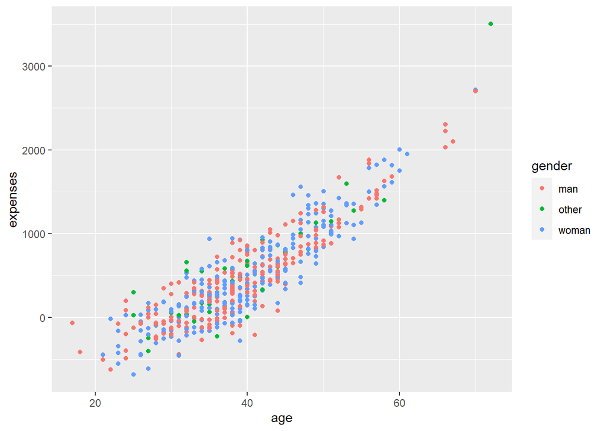

Przeanalizyjmy teraz model za pomocą wykresów diagnostycznych.

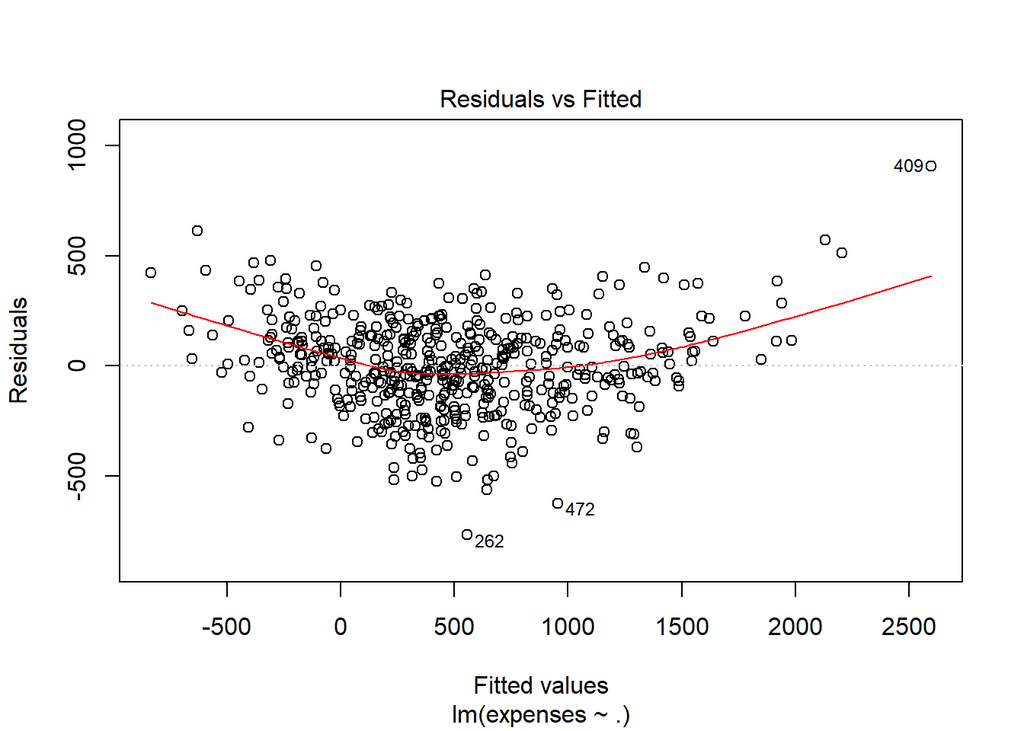

Dzięki temu wykresowi możemy zobaczyć czy zależność danych jest liniowa. Widzimy, że tam gdzie mamy dużo danych czerwona linia bardzo przypomina prostą. Dalej, mamy do czynienia z małą liczbą danych i krzywa zaczyna się wykrzywiać.

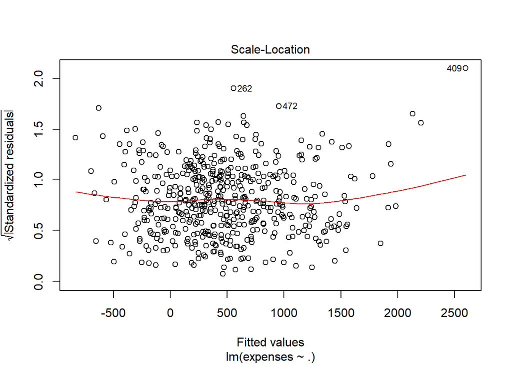

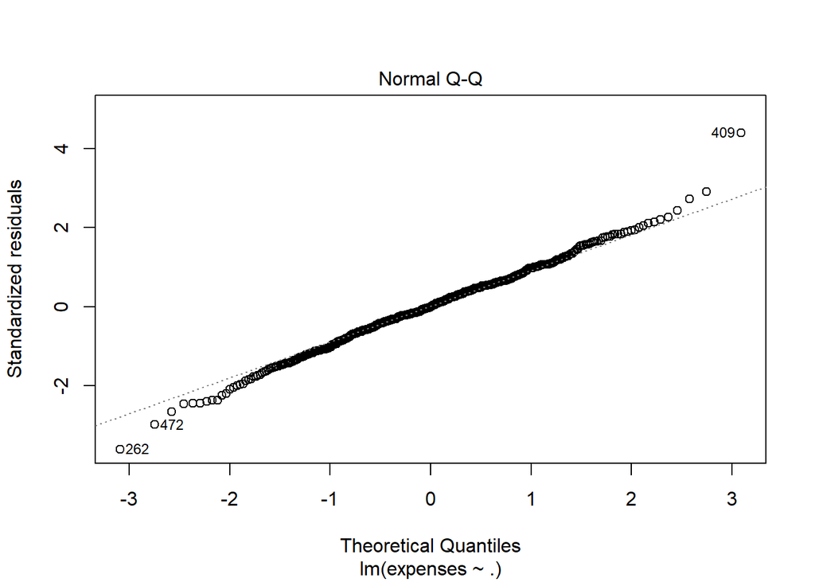

Widzimy, że rozkład residuów jest bardzo zbliżony do rozkłądu normalnego. Nie musimy przeprowadzać żadnych transofrmacji zmiennych.

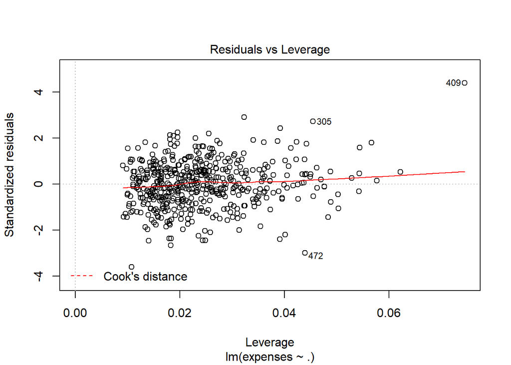

Wykres przedstawia jaki wpływ na ocenę współczyników ma dana oserwacja. Widzimy, że wartości residuów nie są znacząco różne od zera, co dobrze świadczy o naszym modelu. Widzimy również małą liczbę danych odstających.

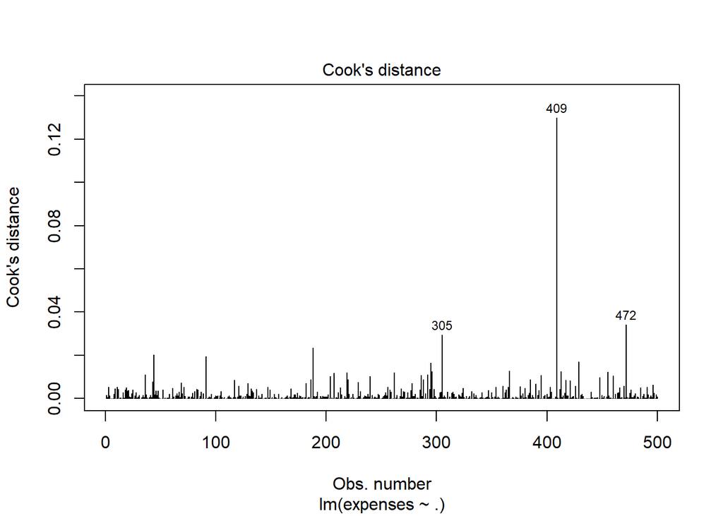

Możemy również przedstawić wpływ każdej obserwacji na postać regresji za pomocą odległości Cooka. Widzimy, trzy wyraźnie odstające dane, jednak dla żadnej z nich odległość jest większa niż 1 więc nie są one wpływowe.

Na koniec policzmy przedział ufności dla parametrów.

```r
confint(linearMod)
```

```
##                        2.5 %       97.5 %
## (Intercept)    -2473.5135002 -2079.977557
## age               55.4840320    59.693688
## weight            -0.7539471     3.169481
## height             0.7707755     3.356657
## genderother      -29.9478322   118.279119
## genderwoman      -61.2894344    17.856718
## marriedTRUE      -60.7877919    41.171958
## number_of_kids   -29.8505420     4.971953
## petdog           -29.8329474    88.371957
## petferret        335.3037468   477.961067
## pethedgehog      171.4885527   312.603360
## petnone          -29.7911599    73.281929
```